# Exercise 11 - Caravans - EDA

## 0. Setup

Load packages.

```r
library(tidyverse)
library(tidymodels)
library(caret)
library(ISLR)
library(GGally)
```

## Caravan data

Save Caravan data as a tibble.

```r
caravan_df <- as_tibble(Caravan)

glimpse(caravan_df)
```

```
Observations: 5,822
Variables: 86
$ MOSTYPE  <dbl> 33, 37, 37, 9, 40, 23, 39, 33, 33, 11, 10, 9, 33, 41, 23, 33, 38, 22, 13, 31, 33, 33, 13, 34, 13, 3…
$ MAANTHUI <dbl> 1, 1, 1, 1, 1, 1, 2, 1, 1, 2, 1, 1, 1, 1, 1, 1, 1, 2, 1, 1, 1, 2, 1, 2, 2, 1, 1, 1, 1, 2, 2, 1, 1, …
$ MGEMOMV  <dbl> 3, 2, 2, 3, 4, 2, 3, 2, 2, 3, 4, 3, 2, 3, 1, 2, 2, 3, 4, 2, 4, 3, 3, 3, 4, 3, 3, 3, 4, 2, 2, 2, 4, …
$ MGEMLEEF <dbl> 2, 2, 2, 3, 2, 1, 2, 3, 4, 3, 3, 3, 3, 3, 2, 3, 3, 3, 2, 4, 3, 3, 2, 2, 3, 3, 3, 3, 2, 3, 2, 2, 3, …
$ MOSHOOFD <dbl> 8, 8, 8, 3, 10, 5, 9, 8, 8, 3, 3, 3, 8, 10, 5, 8, 9, 5, 3, 7, 8, 8, 3, 8, 3, 8, 8, 10, 7, 8, 5, 5, …
$ MGODRK   <dbl> 0, 1, 0, 2, 1, 0, 2, 0, 0, 3, 1, 1, 1, 0, 0, 0, 0, 0, 2, 0, 0, 0, 1, 0, 0, 0, 0, 0, 0, 0, 1, 2, 1, …
$ MGODPR   <dbl> 5, 4, 4, 3, 4, 5, 2, 7, 1, 5, 4, 3, 4, 5, 6, 7, 6, 5, 4, 2, 6, 4, 7, 7, 4, 6, 5, 3, 9, 7, 3, 4, 4, …
$ MGODOV   <dbl> 1, 1, 2, 2, 1, 0, 0, 0, 3, 0, 1, 2, 1, 0, 1, 0, 0, 0, 0, 0, 0, 2, 0, 0, 2, 1, 0, 0, 0, 1, 2, 2, 1, …
$ MGODGE   <dbl> 3, 4, 4, 4, 4, 5, 5, 2, 6, 2, 4, 4, 4, 4, 2, 2, 3, 4, 3, 7, 3, 3, 2, 2, 4, 2, 4, 6, 0, 2, 4, 4, 5, …
$ MRELGE   <dbl> 7, 6, 3, 5, 7, 0, 7, 7, 6, 7, 7, 7, 6, 7, 1, 7, 7, 7, 7, 9, 9, 7, 7, 7, 8, 6, 7, 9, 5, 5, 2, 7, 8, …
$ MRELSA   <dbl> 0, 2, 2, 2, 1, 6, 2, 2, 0, 0, 1, 1, 2, 1, 2, 2, 0, 0, 0, 0, 0, 0, 0, 2, 1, 0, 2, 0, 0, 1, 4, 1, 1, …
$ MRELOV   <dbl> 2, 2, 4, 2, 2, 3, 0, 0, 3, 2, 2, 2, 3, 1, 6, 0, 2, 2, 2, 0, 0, 2, 2, 0, 1, 3, 0, 0, 4, 4, 3, 2, 1, …
$ MFALLEEN <dbl> 1, 0, 4, 2, 2, 3, 0, 0, 3, 2, 0, 2, 3, 1, 5, 0, 0, 0, 1, 0, 0, 0, 1, 0, 1, 2, 0, 0, 0, 4, 3, 6, 1, …
```

[output cut: 73 more lines]

```r
# Number of NA values
caravan_df %>%
  select(-Purchase) %>%
  summarise_all(~sum(is.na(.)))
```

| MOSTYPE | MAANTHUI | MGEMOMV | MGEMLEEF | MOSHOOFD | MGODRK | MGODPR | MGODOV | MGODGE | MRELGE | MRELSA | MRELOV | MFALLEEN | MFGEKIND | MFWEKIND | MOPLHOOG | MOPLMIDD | MOPLLAAG | MBERHOOG | MBERZELF | MBERBOER | MBERMIDD | MBERARBG | MBERARBO | MSKA | MSKB1 | MSKB2 | MSKC | MSKD | MHHUUR | … |
| --- | --- | --- | --- | --- | --- | --- | --- | --- | --- | --- | --- | --- | --- | --- | --- | --- | --- | --- | --- | --- | --- | --- | --- | --- | --- | --- | --- | --- | --- | --- |
| 0 | 0 | 0 | 0 | 0 | 0 | 0 | 0 | 0 | 0 | 0 | 0 | 0 | 0 | 0 | 0 | 0 | 0 | 0 | 0 | 0 | 0 | 0 | 0 | 0 | 0 | 0 | 0 | 0 | 0 | … |

```r
# Minimum values
caravan_df %>%
  select(-Purchase) %>%
  summarise_all(min)
```

| MOSTYPE | MAANTHUI | MGEMOMV | MGEMLEEF | MOSHOOFD | MGODRK | MGODPR | MGODOV | MGODGE | MRELGE | MRELSA | MRELOV | MFALLEEN | MFGEKIND | MFWEKIND | MOPLHOOG | MOPLMIDD | MOPLLAAG | MBERHOOG | MBERZELF | MBERBOER | MBERMIDD | MBERARBG | MBERARBO | MSKA | MSKB1 | MSKB2 | MSKC | MSKD | MHHUUR | … |
| --- | --- | --- | --- | --- | --- | --- | --- | --- | --- | --- | --- | --- | --- | --- | --- | --- | --- | --- | --- | --- | --- | --- | --- | --- | --- | --- | --- | --- | --- | --- |
| 1 | 1 | 1 | 1 | 1 | 0 | 0 | 0 | 0 | 0 | 0 | 0 | 0 | 0 | 0 | 0 | 0 | 0 | 0 | 0 | 0 | 0 | 0 | 0 | 0 | 0 | 0 | 0 | 0 | 0 | … |

```r
# Maximum vaues
caravan_df %>%
  select(-Purchase) %>%
  summarise_all(max)
```

| MOSTYPE | MAANTHUI | MGEMOMV | MGEMLEEF | MOSHOOFD | MGODRK | MGODPR | MGODOV | MGODGE | MRELGE | MRELSA | MRELOV | MFALLEEN | MFGEKIND | MFWEKIND | MOPLHOOG | MOPLMIDD | MOPLLAAG | MBERHOOG | MBERZELF | MBERBOER | MBERMIDD | MBERARBG | MBERARBO | MSKA | MSKB1 | MSKB2 | MSKC | MSKD | MHHUUR | … |
| --- | --- | --- | --- | --- | --- | --- | --- | --- | --- | --- | --- | --- | --- | --- | --- | --- | --- | --- | --- | --- | --- | --- | --- | --- | --- | --- | --- | --- | --- | --- |
| 41 | 10 | 5 | 6 | 10 | 9 | 9 | 5 | 9 | 9 | 7 | 9 | 9 | 9 | 9 | 9 | 9 | 9 | 9 | 5 | 9 | 9 | 9 | 9 | 9 | 9 | 9 | 9 | 9 | 9 | … |

```r
# Unique values for each variable
caravan_df %>%
  map(~sort(unique(.)))
```

```
$MOSTYPE
 [1]  1  2  3  4  5  6  7  8  9 10 11 12 13 15 16 17 18 19 20 21 22 23 24 25 26 27 28 29 30 31 32 33 34 35 36 37 38 39
[39] 40 41

$MAANTHUI
[1]  1  2  3  4  5  6  7  8 10

$MGEMOMV
[1] 1 2 3 4 5

$MGEMLEEF
[1] 1 2 3 4 5 6

$MOSHOOFD
 [1]  1  2  3  4  5  6  7  8  9 10

$MGODRK
 [1] 0 1 2 3 4 5 6 7 8 9

$MGODPR
 [1] 0 1 2 3 4 5 6 7 8 9

$MGODOV
[1] 0 1 2 3 4 5

$MGODGE
 [1] 0 1 2 3 4 5 6 7 8 9

$MRELGE
 [1] 0 1 2 3 4 5 6 7 8 9

$MRELSA
[1] 0 1 2 3 4 5 6 7

$MRELOV
 [1] 0 1 2 3 4 5 6 7 8 9

$MFALLEEN
 [1] 0 1 2 3 4 5 6 7 8 9

```

[output cut: 204 more lines]

```
$APLEZIER
[1] 0 1 2

$AFIETS
[1] 0 1 2 3

$AINBOED
[1] 0 1 2

$ABYSTAND
[1] 0 1 2

$Purchase
[1] No  Yes
Levels: No Yes
```

# EDA

Plot charts of variables vs response variable.

```r
# First 10 variables
caravan_df %>%
  select(1:10, "Purchase") %>%
  gather(1:10, key = "variable", value = "value") %>%
  ggplot(aes(variable, value, colour = Purchase)) +
  geom_boxplot() +
  theme(axis.text.x = element_text(angle = 90, hjust = 1))

# 11 to 20 variables (10)
caravan_df %>%
  select(11:20, "Purchase") %>%
  gather(1:10, key = "variable", value = "value") %>%
  ggplot(aes(variable, value, colour = Purchase)) +
  geom_boxplot() +
  theme(axis.text.x = element_text(angle = 90, hjust = 1))

# 20
caravan_df %>%
  select(21:30, "Purchase") %>%
  gather(1:10, key = "variable", value = "value") %>%
  ggplot(aes(variable, value, colour = Purchase)) +
  geom_boxplot() +
  theme(axis.text.x = element_text(angle = 90, hjust = 1))

# 30
caravan_df %>%
  select(31:40, "Purchase") %>%
  gather(1:10, key = "variable", value = "value") %>%
  ggplot(aes(variable, value, colour = Purchase)) +
  geom_boxplot() +
  theme(axis.text.x = element_text(angle = 90, hjust = 1))

# 40
caravan_df %>%
  select(41:50, "Purchase") %>%
  gather(1:10, key = "variable", value = "value") %>%
  ggplot(aes(variable, value, colour = Purchase)) +
  geom_boxplot() +
  theme(axis.text.x = element_text(angle = 90, hjust = 1))

# 50
caravan_df %>%
  select(51:60, "Purchase") %>%
  gather(1:10, key = "variable", value = "value") %>%
  ggplot(aes(variable, value, colour = Purchase)) +
  geom_boxplot() +
  theme(axis.text.x = element_text(angle = 90, hjust = 1))

# 60
caravan_df %>%
  select(61:70, "Purchase") %>%
  gather(1:10, key = "variable", value = "value") %>%
  ggplot(aes(variable, value, colour = Purchase)) +
  geom_boxplot() +
  theme(axis.text.x = element_text(angle = 90, hjust = 1))

# 70
caravan_df %>%
  select(71:80, "Purchase") %>%
  gather(1:10, key = "variable", value = "value") %>%
  ggplot(aes(variable, value, colour = Purchase)) +
  geom_boxplot() +
  theme(axis.text.x = element_text(angle = 90, hjust = 1))

# 80
caravan_df %>%
  select(81:85, "Purchase") %>%
  gather(1:5, key = "variable", value = "value") %>%
  ggplot(aes(variable, value, colour = Purchase)) +
  geom_boxplot() +
  theme(axis.text.x = element_text(angle = 90, hjust = 1))
```

[output not shown]

The boxplots are only useful up to variable 40. Of these 40, the variables which look most promising for classifying cases as Purchase = Yes or No are: MRELGE, MOPLMIDD, MHHUUR, MSKA, MOSHOOFD, MOSTYPE, MHKOOP, MZFONDS, PWAPART.

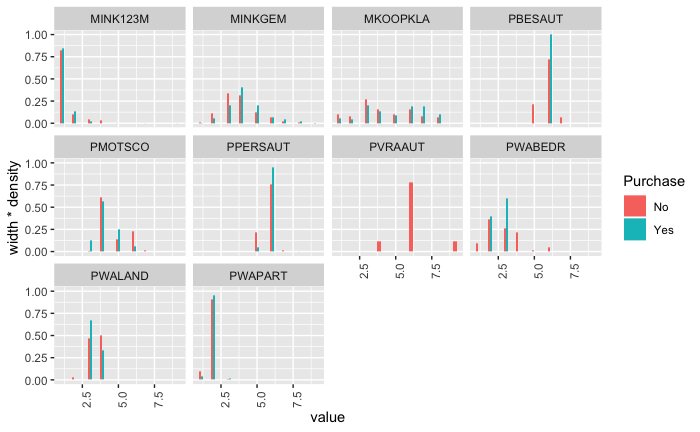

```r
# 41 to 50 (40)
caravan_df %>%
  select(41:50, "Purchase") %>%
  gather(1:10, key = "variable", value = "value") %>%
  filter(round(value, 4) != 0) %>%
  ggplot(aes(value, fill = Purchase)) +
  geom_histogram(aes(y = stat(width*density)), position = "dodge") +
  facet_wrap(~ variable) +
  theme(axis.text.x = element_text(angle = 90, hjust = 1))
```

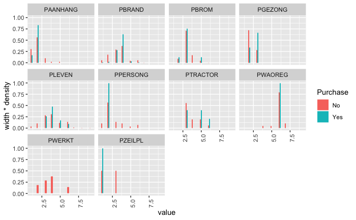

```r
# 50
caravan_df %>%
  select(51:60, "Purchase") %>%
  gather(1:10, key = "variable", value = "value") %>%
  filter(round(value, 4) != 0) %>%
  ggplot(aes(value, fill = Purchase)) +
  geom_histogram(aes(y = stat(width*density)), position = "dodge") +
  facet_wrap(~ variable) +
  theme(axis.text.x = element_text(angle = 90, hjust = 1))
```

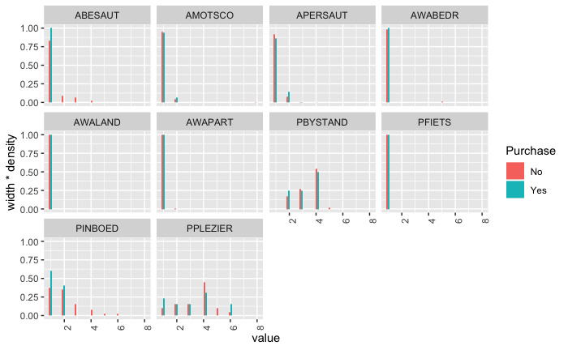

```r
# 60
caravan_df %>%
  select(61:70, "Purchase") %>%
  gather(1:10, key = "variable", value = "value") %>%
  filter(round(value, 4) != 0) %>%
  ggplot(aes(value, fill = Purchase)) +
  geom_histogram(aes(y = stat(width*density)), position = "dodge") +
  facet_wrap(~ variable) +
  theme(axis.text.x = element_text(angle = 90, hjust = 1))
```

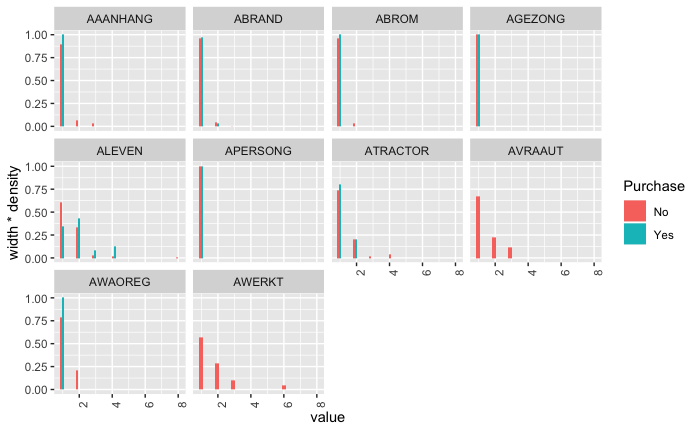

```r
# 70
caravan_df %>%
  select(71:80, "Purchase") %>%
  gather(1:10, key = "variable", value = "value") %>%
  filter(round(value, 4) != 0) %>%
  ggplot(aes(value, fill = Purchase)) +
  geom_histogram(aes(y = stat(width*density)), position = "dodge") +
  facet_wrap(~ variable) +
  theme(axis.text.x = element_text(angle = 90, hjust = 1))
```

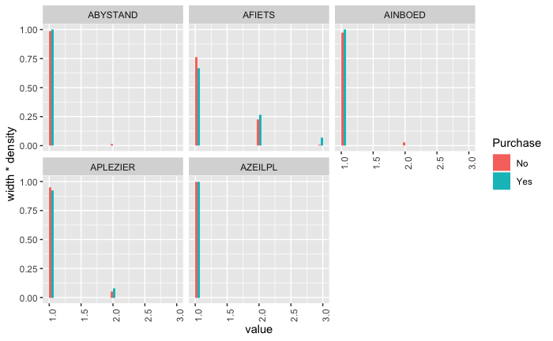

```r
# 81 to 85
caravan_df %>%
  select(81:85, "Purchase") %>%
  gather(1:5, key = "variable", value = "value") %>%
  filter(round(value, 4) != 0) %>%
  ggplot(aes(value, fill = Purchase)) +
  geom_histogram(aes(y = stat(width*density)), position = "dodge") +
  facet_wrap(~ variable) +
  theme(axis.text.x = element_text(angle = 90, hjust = 1))
```

From variables 41 to 85, the followin appear to differentiate between Purchase = Yes and Purchase = No the best: PBESAUT, PVRAAUT, PWABEDR, PWERKT, AVRAAUT, AWERKT, PPERSONG, PGEZONG, PZEILPL.

Select the variables from 1 to 40 which appear to have the best predictive power and check to see if any correlations between these variables.

```r
vars_spread <-
  c(
    "MRELGE",
    "MOPLMIDD",
    "MHHUUR",
    "MSKA",
    "MOSHOOFD",
    "MOSTYPE",
    "MHKOOP",
    "MZFONDS",
    "PWAPART"
  )

# Correlation matrix
caravan_df %>%
  select(one_of(vars_spread)) %>%
  ggcorr(nbreaks=8, palette='RdGy', label=TRUE, label_size=5, label_color='white')
```

[output not shown]

There is a clear correlation between MOSHOOFD and MOSTYPE. It looks like MOSTYPE is a subcategory of MOSHOOFD. Only include MOSTYPE as this includes more information (wider range of values).

It is less clear that there is an obvious relationship betwen MZFONDS and MHKOOP despite the correlation of -1.

```r
# Investigate pairs of variables wih high correlations further.
my_bin <-
  function(data,
           mapping,
           ...,
           low = "#132B43",
           high = "#56B1F7") {
    ggplot(data = data, mapping = mapping) +
      geom_bin2d(...) +
      scale_fill_gradient(low = low, high = high)
  }

caravan_df %>%
  select(one_of(c("MOSHOOFD", "MOSTYPE", "MZFONDS", "MHKOOP")), "Purchase") %>%
  ggpairs(columns = 1:4, lower = list(continuous = wrap(
    my_bin, binwidth = c(0.5, 0.5), high = "red"
  )))
```

[output not shown]

Repeat for variables 41 to 85

```r
vars_spread_2 <-
  c(
    "BESAUT",
    "PVRAAUT",
    "PWABEDR",
    "PWERKT",
    "AVRAAUT",
    "AWERKT",
    "PPERSONG",
    "PGEZONG",
    "PZEILPL"
  )

# Correlation matrix
caravan_df %>%
  select(one_of(vars_spread_2)) %>%
  ggcorr(nbreaks=8, palette='RdGy', label=TRUE, label_size=5, label_color='white')
```

[output not shown]

Investigate pairs AWERKT & PWERKT, and AVRAAUT & PVRAAUT further as have high positive high correlations. Chart does suggest highly correlated.

Use PVRAAUT instead of AVRAAUT as more distinction on Purchase. Use PWERKT instead of AWERKT for same reason.

```r
caravan_df %>%
  select(one_of(c("AWERKT", "PWERKT", "AVRAAUT", "PVRAAUT")), "Purchase") %>%
  ggpairs(columns = 1:4, lower = list(continuous = wrap(
    my_bin, binwidth = c(0.5, 0.5), high = "red"
  )))
```

[output not shown]

Left with the following variables to use.

```r
var_mod <-   c(
    "MRELGE",
    "MOPLMIDD",
    "MHHUUR",
    "MSKA",
    "MOSTYPE",
    "MHKOOP",
    "MZFONDS",
    "PWAPART",
    "BESAUT",
    "PVRAAUT",
    "PWABEDR",
    "PWERKT",
    "PPERSONG",
    "PGEZONG",
    "PZEILPL"
  )

write.csv(var_mod, "var_mod.csv")
```

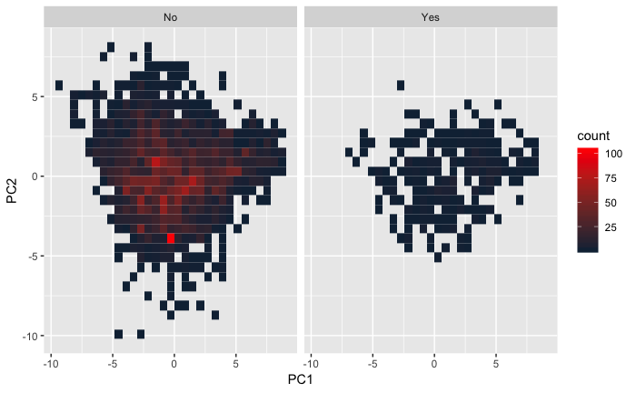

Repeat with selected variables. Again, there is not a clear separation.

```r
pr_out <- caravan_df %>%
  select(-Purchase) %>%
  select(one_of(var_mod)) %>%
  prcomp(scale = TRUE)
```

```
Unknown columns: `BESAUT`
```

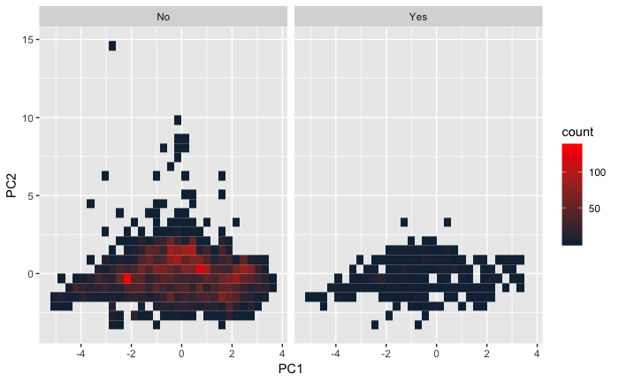

```r
pr_vectors <- pr_out$x %>%
  as_tibble()

pr_vectors$Purchase <- caravan_df$Purchase

ggplot(pr_vectors, aes(x = PC1, y = PC2)) +
  geom_bin2d() +
      scale_fill_gradient(high = "red") +
  facet_wrap(~Purchase)
```

Plot scree plot of principal components, see how much of the variance the two principal components explain, if they do not explain much then might still be able to differentiate between purchase = yes and no using the variables.

There is a clear drop off after the first principal component, but fairly level after that, and the first principal component only accounts for around 20% of the variation.

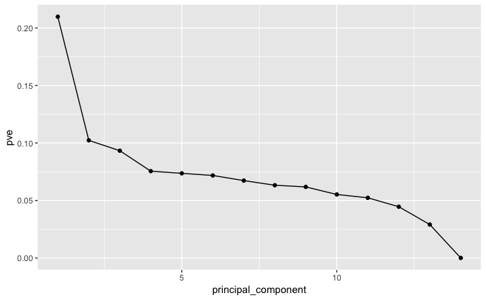

```r
pca_pve <- summary(pr_out)$importance

pca_pve <- pca_pve %>%
  t() %>%
  as_tibble()

names(pca_pve) <- c("st_dev", "pve", "cumulative_pve")

pca_pve$principal_component <- 1:14

ggplot(pca_pve, aes(principal_component, pve)) +
  geom_point() +
  geom_line()
```